# Predicting the Number of Bike Shares

## Bagging

In this section, the bagging shall be performed on the regression tree model to reduce the variance. As y-variable not the class is used but cnt. The number of Bootstrap replication is set to 25. It should no cross validation be used as set with parameter coob.

```r
bag.bike=bagging(cnt~.-class, data=d.bike.train.new, nbagg=25, coob =TRUE)
print(bag.bike)
```

```
##
## Bagging regression trees with 25 bootstrap replications
##
## Call: bagging.data.frame(formula = cnt ~ . - class, data = d.bike.train.new,
##     nbagg = 25, coob = TRUE)
##
## Out-of-bag estimate of root mean squared error:  51.1638
```

Now prediction is to be performed by means of bagging on the test set. The result is plotted.

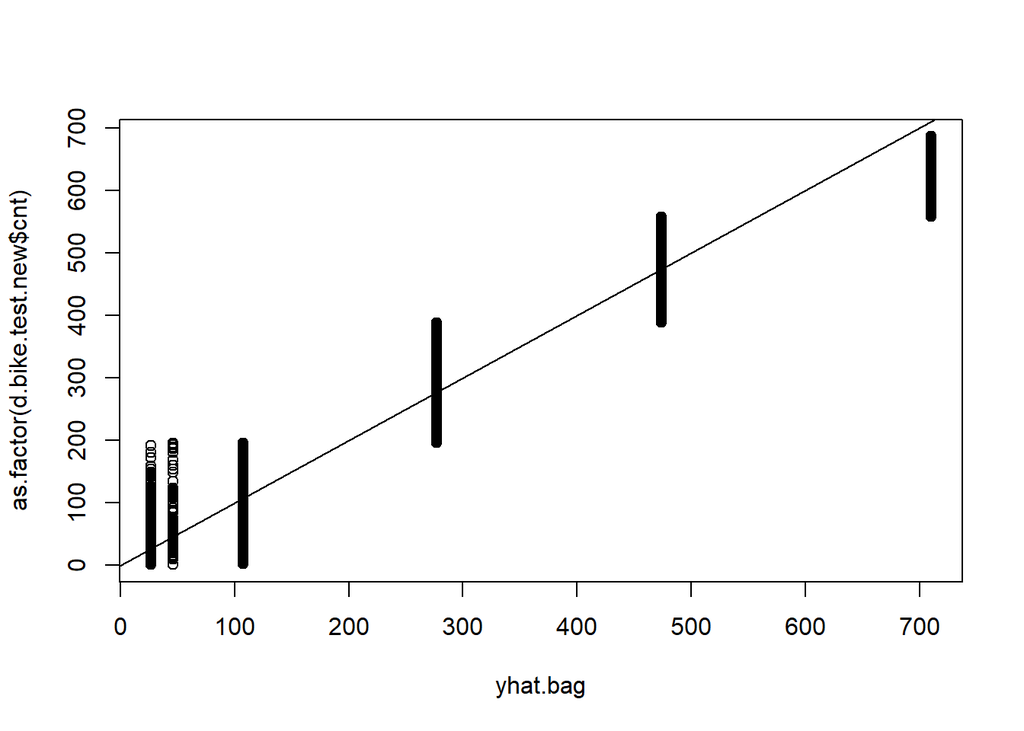

```r
yhat.bag = predict(bag.bike,newdata=d.bike.test.new)
plot(yhat.bag, as.factor(d.bike.test.new$cnt))
abline(0,1)
```

The graphic representation shows us what the MSE has already shown us. The devinace from the estimate (straight line) and thus the variance is large.

```r
mean((yhat.bag-d.bike.test.new$cnt)^2)
```

```
## [1] 2652.006
```

The calculation of the MSE from the forecast confirms this a second time.

## Random Forest

In this section the random forest method is used for the already discussed analysis. However, here the “class” variable is used as the target value instead of the “cnt” variable. The random forest function could not handle cnt because it has too many levels (see https://stats.stackexchange.com/questions/37370/random-forest-computing-time-in-r) . Mtry is set to 6 for this anlysis.

The aim of this analysis is to calculate an MSE value again and to investigate the importance of the individual explaining variables.

run the initial function:

```r
rf.bike=randomForest(as.numeric(as.character(class)) ~ .-cnt,data=d.bike.train.new, mtry=6,importance =TRUE)
```

predict on test set:

```r
yhat.rf = predict(rf.bike ,newdata=d.bike.test.new)
```

```r
mean((yhat.rf-d.bike.test.new$class)^2)
```

```
## [1] 0.2264341
```

With the two masses “increase of MSE in percent” and “inrease in node purity” it can be seen that “hr” is by far the most important variable. This can be seen in the table and graphic below:

```r
importance(rf.bike)
```

```
##              %IncMSE IncNodePurity
## season      64.31021      286.7481
## yr         229.76703     1028.8263
## mnth        73.34177      574.5719
## hr         504.17684     4329.8716
## weathersit  71.58506      277.5074
## temp        58.55109     1087.6280
## atemp       49.33936      941.7789
## hum         80.86539      889.7663
```

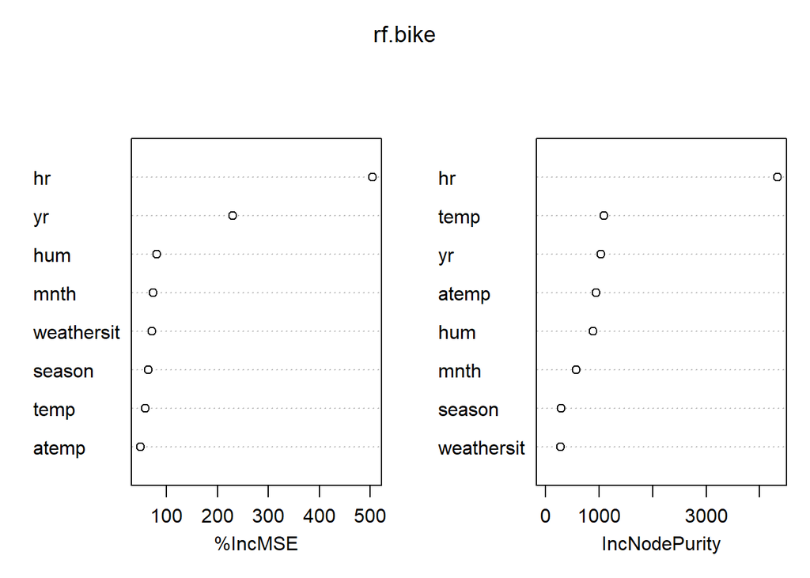

```r
varImpPlot (rf.bike)
```

## Boosting

In this section Boosting will be used to improve the model. Since our data set is count data, we choose the Poisson distribution. The number of trees to be generated in boosting is set to 1000.

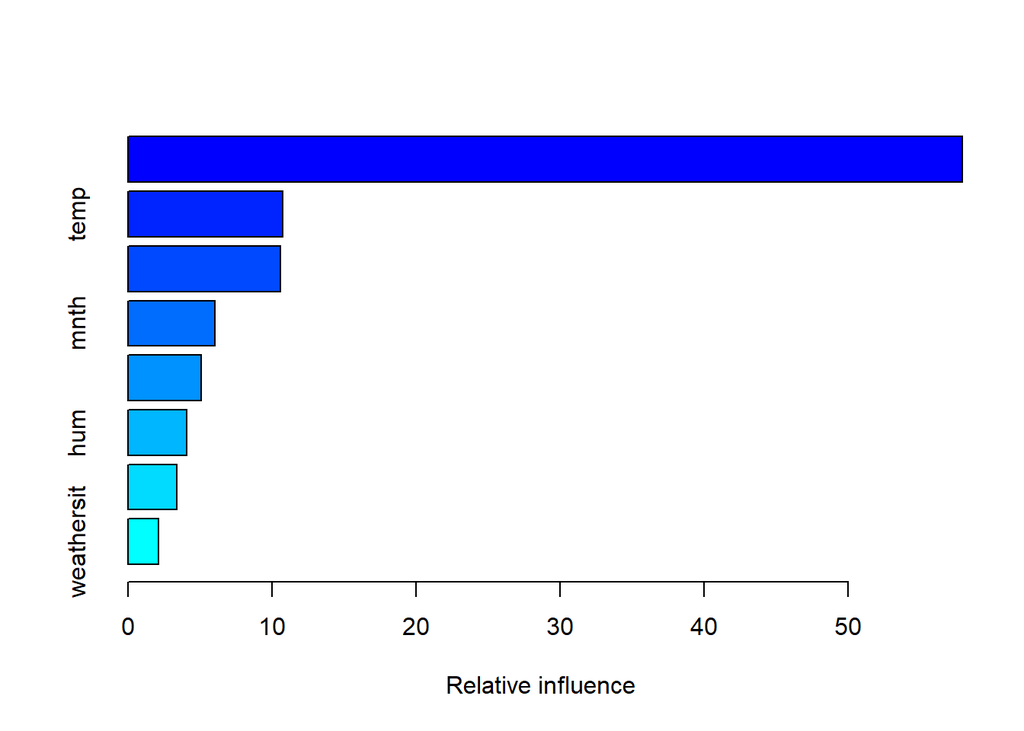

```
##                   var   rel.inf
## hr                 hr 57.949487
## temp             temp 10.757371
## yr                 yr 10.610432
## mnth             mnth  6.013127
## atemp           atemp  5.112039
## hum               hum  4.080221
## season         season  3.380834
## weathersit weathersit  2.096489
```

```r
boost.bike=gbm(cnt~.-class,data=d.bike.train.new,
               distribution="poisson",n.trees=1000, interaction.depth=4)
summary(boost.bike)
```

By far the most important attribute is hr. As the result shows the attributes yr and temp are also important. This is not surprising, since the tree developed in the section “Classification Tree” was already based on these three attributes.

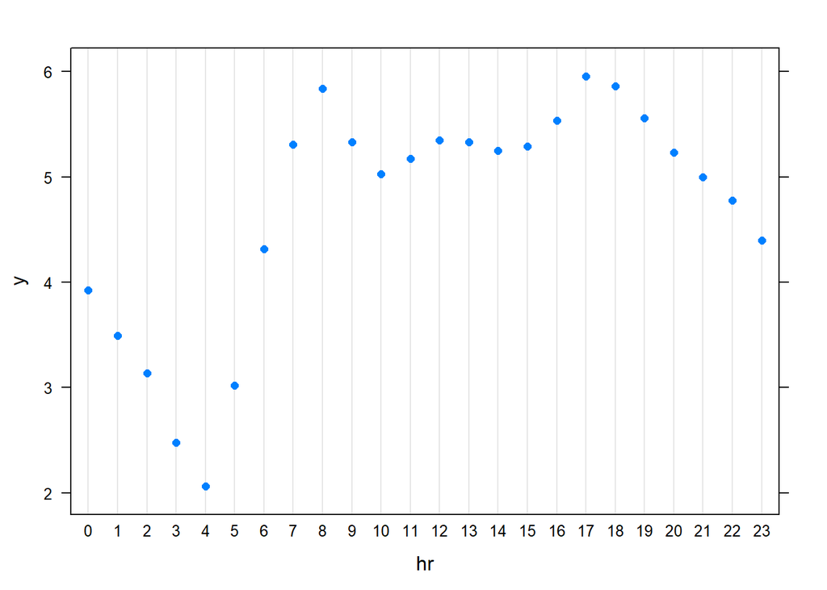

```r
plot(boost.bike ,i="hr")
```

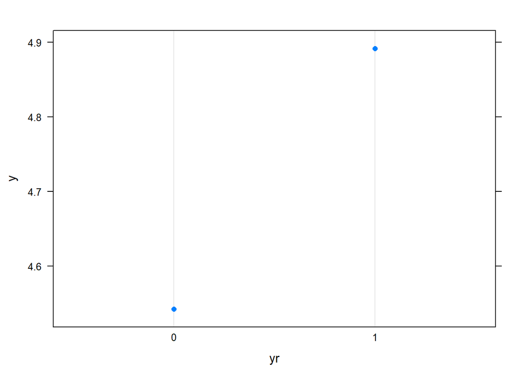

```r
plot(boost.bike ,i="yr")
```

A prediction is performed to check performance on the test data record. As in the previous examples, performance is assessed using MSE.

```r
yhat.boost=predict(boost.bike,newdata=d.bike.test.new, n.trees=1000)
mean((yhat.boost -d.bike.test.new$cnt)^2)
```

```
## [1] 65722.08
```

# 5. Support Vector Machines

The fifth chapter deals with the classification of data using Support Vector Machines (SVM). Two SVMs are trained and tested. In the first case, the data is classified into two classes using SVM with two predictors. In the second case, the data is classified in five classes using the final model.

## 2-class linear SVM with casual und atemp

An interesting classification is the division of the data in cyclists without subscription (casual) into those who ride during cool temperatures and those who ride during very warm temperatures. The two attributes casual and breath are considered. In a plot, a quite centered seperating hyperplane is supposed to divide the data into two classes. For this purpose an intercept of the x-value atemp of 0.5525 is defined straight-forward, which separates the two types of cyclist visually.

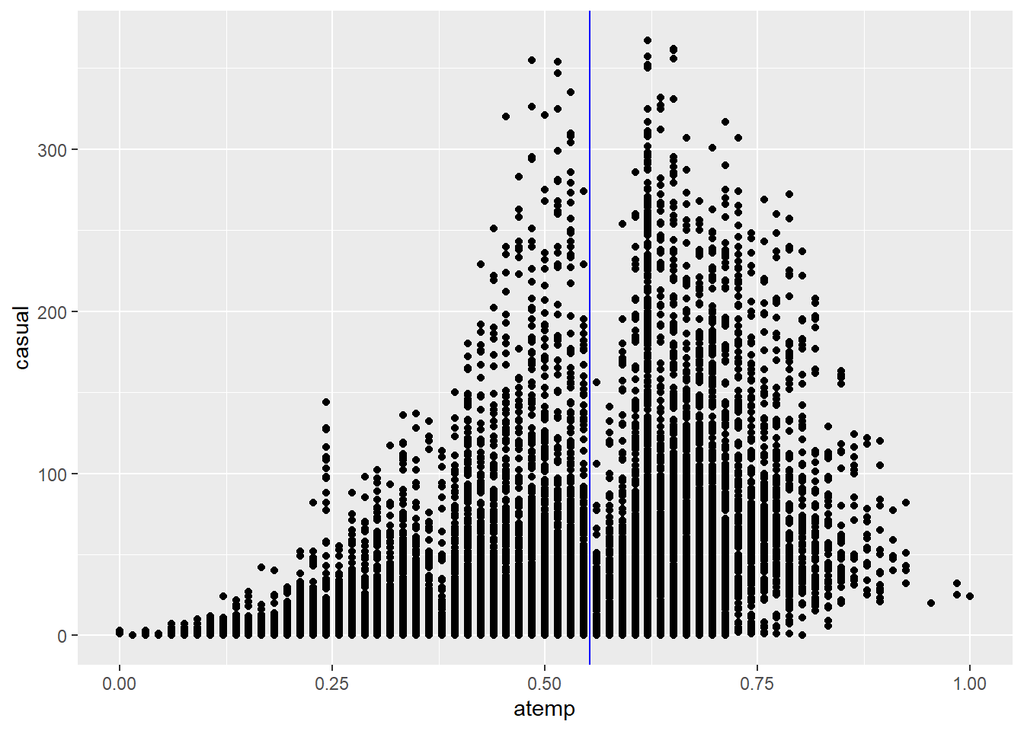

```r
xi <- 0.5525
ggplot(data = d.bike, mapping = aes(y = casual, x = atemp)) + geom_point() + geom_vline(xintercept = xi, color = "blue")
```

The scatterplot shows the blue hyperplane.

The next step is to classify the data so that the SVM model knows which classes to determine. This is a prerequisite in the classification. A simple if-statement can be defined for classification. If atemp is smaller than the vertical intercept defined in the visual example, it is class 0, i.e. those cyclists without a subscription who rent a bicycle even at cooler temperatures. If the observed atemp is greater than or equal to the defined intercept of 0.5525, then we are dealing with class 1, i.e. a cyclist who rents a bicycle even in warmer temperatures. A for-loop is used to perform the classification for each observed value.

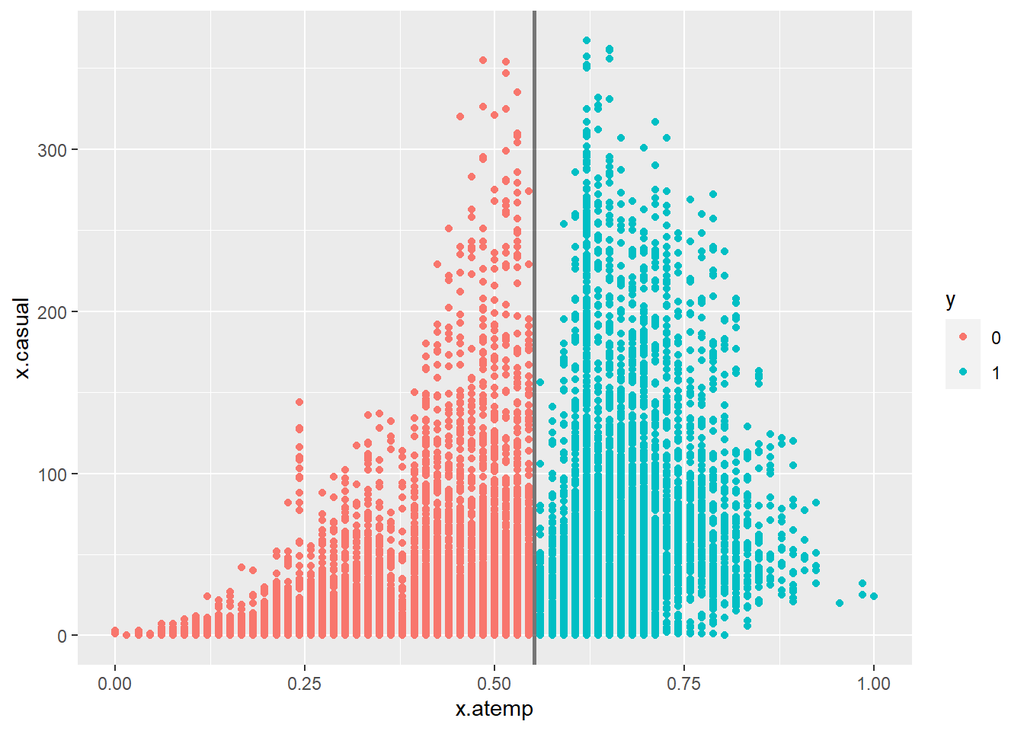

```r
for(i in 1:nrow(d.bike)){
  if(d.bike$atemp[i] < 0.5525){
    d.bike$class[i] <- 0
  } else if (d.bike$atemp[i] >= 0.5525){
    d.bike$class[i] <- 1
  }
}

c.bike <- data.frame(x=d.bike, y=as.factor(d.bike$class))
ggplot(data = c.bike, mapping = aes(y = x.casual, x = x.atemp,  color=y)) + geom_point() + geom_vline(xintercept = xi, size = 1, alpha = 0.5)
```

The figure shows the two classes separated by color.

Now that the classes and thus the target variable are defined, an SVM model can be fitted. As can be seen from the summary, 628 support vectors are available at the cost of 10. 316 of them are in class 0 and 312 in class 1.

```r
svm.bike.1 <- svm(y~x.casual+x.atemp,
                  data = c.bike,
                  kernel = "linear",
                  cost = 10,
                  scale = FALSE)
summary(svm.bike.1)
```

```
##
## Call:
## svm(formula = y ~ x.casual + x.atemp, data = c.bike, kernel = "linear",
##     cost = 10, scale = FALSE)
##
##
## Parameters:
##    SVM-Type:  C-classification
##  SVM-Kernel:  linear
##        cost:  10
##
## Number of Support Vectors:  628
##
##  ( 316 312 )
##
##
## Number of Classes:  2
##
## Levels:
##  0 1
```

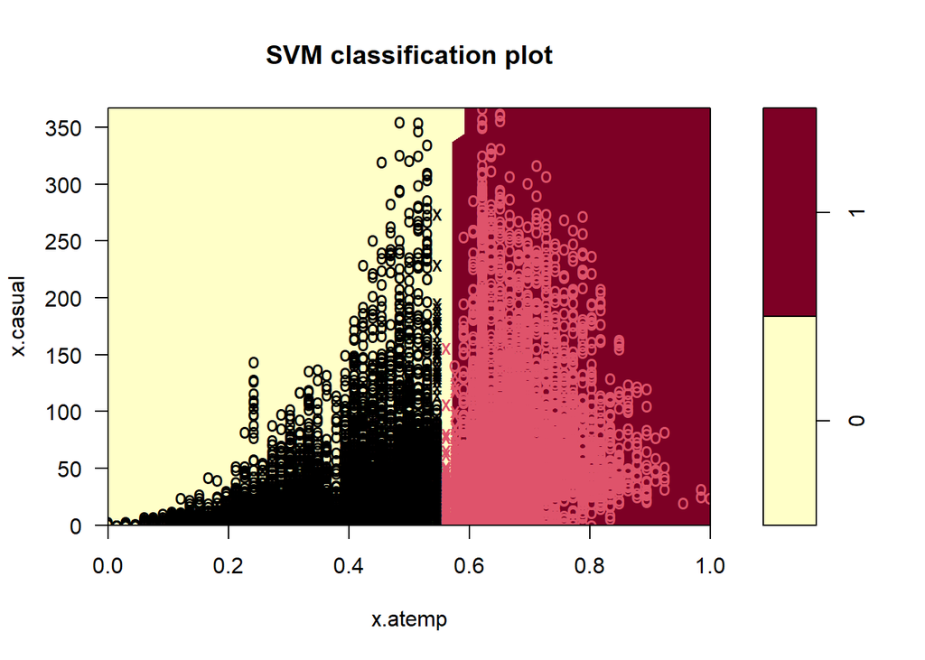

```r
plot(svm.bike.1, c.bike, x.casual~x.atemp)
```

The plot shows the classification and the support vectors.

In order to obtain the best model with optimal cost factor, a vector with different cost values is first defined and the tune-function is used.

```r
cost_range <-
  c(0.01,
    0.1,
    1,
    5,
    10,
    100)

tune.out <- tune(
  svm,
  y ~ x.casual+x.atemp,
  data = c.bike,
  kernel = "linear",
  ranges = list(cost = cost_range)
)
summary(tune.out)
```

```
##
## Parameter tuning of 'svm':
##
## - sampling method: 10-fold cross validation
##
## - best parameters:
##  cost
##     1
##
## - best performance: 0
##
## - Detailed performance results:
##    cost        error   dispersion
## 1 1e-02 0.0104725354 0.0025566324
## 2 1e-01 0.0002301827 0.0002971646
## 3 1e+00 0.0000000000 0.0000000000
## 4 5e+00 0.0000000000 0.0000000000
## 5 1e+01 0.0000000000 0.0000000000
## 6 1e+02 0.0000000000 0.0000000000
```

As can be seen, with a cost factor of 1, an error rate of 0 is already possible.

```r
svm.bike.1.best <- tune.out$best.model
summary(svm.bike.1.best)
```

```
##
## Call:
## best.tune(method = svm, train.x = y ~ x.casual + x.atemp, data = c.bike,
##     ranges = list(cost = cost_range), kernel = "linear")
##
##
## Parameters:
##    SVM-Type:  C-classification
##  SVM-Kernel:  linear
##        cost:  1
##
## Number of Support Vectors:  366
##
##  ( 184 182 )
##
##
## Number of Classes:  2
##
## Levels:
##  0 1
```

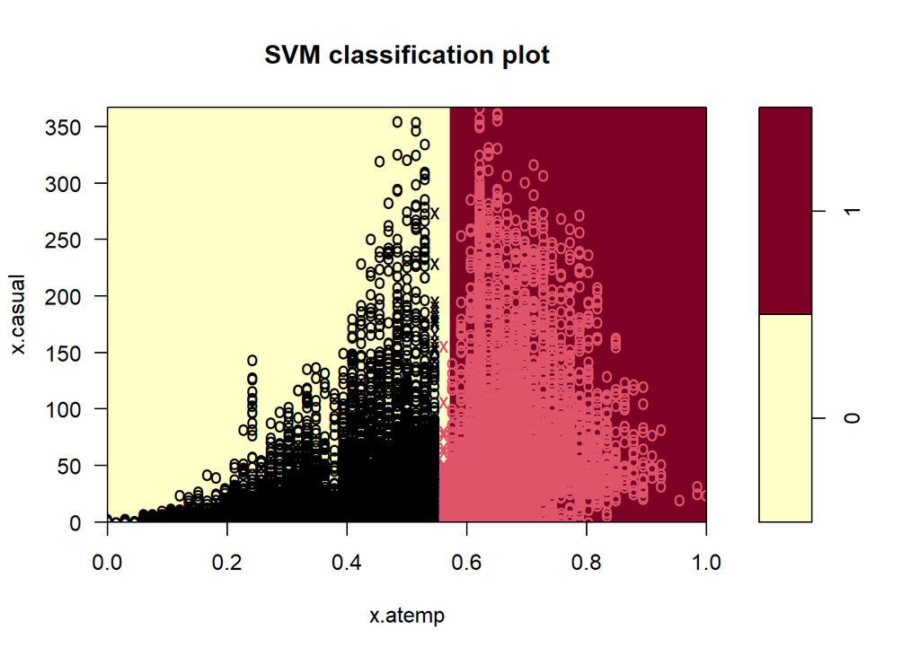

```r
plot(svm.bike.1.best, c.bike, x.casual~x.atemp)
```

The result of the best model shows us this. The best model has an optimal cost factor of 1 and consequently there are less support vectors. It is a little more than half of the first model.

```r
table(predict = predict(svm.bike.1.best, c.bike),
      truth = c.bike$y)
```

```
##        truth
## predict     0     1
##       0 11148     0
##       1     0  6231
```

As the table shows, no errors are made in the prediction and the data is correctly classified.

## 5-class linear SVM with the developed model

In the second section of this chapter, a classification into five classes based on the final.model.1 will be made. The same classes are used that were already generated in the “Classification Tree” section. Due to the multi-dimensionality (more than 3 predictors), the SVM classification cannot be visualized.

To be able to fit an SVM model, the two data sets must be transformed.The class is removed from the x-variables and assigned as factor to the y-variable, i.e. the target variable.

```r
d.bike.train.svm <- data.frame(x=subset(d.bike.train.new, select=-c(class)), y=as.factor(d.bike.train.new$class))
d.bike.test.svm <- data.frame(x=subset(d.bike.test.new, select=-c(class)), y=as.factor(d.bike.test.new$class))
```

Now the model can be fitted. The cost factor is deliberately set low, so that errors in the classification occur first, which are then to be eliminated with the tuning. At this point it should also be noted that the model in this example is now fitted with the training data record.

```r
svm.bike.2 <- svm(y ~ .,
                  data = d.bike.train.svm,
                  kernel = "linear",
                  cost = 0.01,
                  metric = "RMSE",
                  scale = FALSE,
)
summary(svm.bike.2)
```

```
##
## Call:
## svm(formula = y ~ ., data = d.bike.train.svm, kernel = "linear",
##     cost = 0.01, metric = "RMSE", , scale = FALSE)
##
##
## Parameters:
##    SVM-Type:  C-classification
##  SVM-Kernel:  linear
##        cost:  0.01
##
## Number of Support Vectors:  154
##
##  ( 43 32 59 16 4 )
##
##
## Number of Classes:  5
##
## Levels:
##  0 1 2 3 4
```

Now the classes are predicted once on the training and once on the test data set.

```r
predict.svm.bike.2.train <- predict(svm.bike.2, d.bike.train.svm)
table(predict.svm.bike.2.train, d.bike.train.svm$y)
```

```
##
## predict.svm.bike.2.train    0    1    2    3    4
##                        0 8011    0    0    0    0
##                        1    0 3208    0    0    0
##                        2    0    0 1254    5    0
##                        3    0    0    0  413    0
##                        4    0    0    0    0  143
```

```r
predict.svm.bike.2.test <- predict(svm.bike.2, d.bike.test.svm)
table(predict.svm.bike.2.test, d.bike.test.svm$y)
```

```
##
## predict.svm.bike.2.test    0    1    2    3    4
##                       0 2631    0    0    0    0
##                       1    0 1133    0    0    0
##                       2    0    0  402    2    0
##                       3    0    0    0  142    0
##                       4    0    0    0    0   35
```

Errors are made on both data sets. These must now be eliminated. To do this, a cost range is initialized as in the first example. The model is again optimized using the tune function.

```r
cost_range <-
  c(0.01,
    0.1,
    1,
    5,
    10,
    100,
    1000)

tune.out <- tune(
  svm,
  y~.,
  data = d.bike.train.svm,
  kernel = "linear",
  ranges = list(cost = cost_range),
  scale = FALSE
  )
summary(tune.out)
```

```
##
## Parameter tuning of 'svm':
##
## - sampling method: 10-fold cross validation
##
## - best parameters:
##  cost
##     1
##
## - best performance: 0.0001534919
##
## - Detailed performance results:
##    cost        error   dispersion
## 1 1e-02 0.0008439703 0.0009872952
## 2 1e-01 0.0004602404 0.0006467446
## 3 1e+00 0.0001534919 0.0003235894
## 4 5e+00 0.0001534919 0.0003235894
## 5 1e+01 0.0001534919 0.0003235894
## 6 1e+02 0.0001534919 0.0003235894
## 7 1e+03 0.0001534919 0.0003235894
```

```r
svm.bike.2.best <- tune.out$best.model
summary(svm.bike.2.best)
```

```
##
## Call:
## best.tune(method = svm, train.x = y ~ ., data = d.bike.train.svm,
##     ranges = list(cost = cost_range), kernel = "linear", scale = FALSE)
##
##
## Parameters:
##    SVM-Type:  C-classification
##  SVM-Kernel:  linear
##        cost:  1
##
## Number of Support Vectors:  58
##
##  ( 15 13 23 5 2 )
##
##
## Number of Classes:  5
##
## Levels:
##  0 1 2 3 4
```

Subsequently, the classes are to be predicted once on the training data set and once on the test data set. Based on the ratio of correct and incorrect classifications, the performance on both data sets will be evaluated.

```r
predict.svm.bike.2.best.train <- predict(svm.bike.2.best, d.bike.train.svm)
table(predict.svm.bike.2.best.train, d.bike.train.svm$y)
```

```
##
## predict.svm.bike.2.best.train    0    1    2    3    4
##                             0 8011    0    0    0    0
##                             1    0 3208    0    0    0
##                             2    0    0 1254    0    0
##                             3    0    0    0  418    0
##                             4    0    0    0    0  143
```

```r
corrects=sum(predict.svm.bike.2.best.train==d.bike.train.svm$y)
errors=sum(predict.svm.bike.2.best.train!=d.bike.train.svm$y)
(performance_train=corrects/(corrects+errors))
```

```
## [1] 1
```

A performance rate of 100% is achieved on the training data record. This can already be seen in the table. All data is assigned to the correct classes.

```r
predict.svm.bike.2.best.test <- predict(svm.bike.2.best, d.bike.test.svm)
table(predict.svm.bike.2.best.test, d.bike.test.svm$y)
```

```
##
## predict.svm.bike.2.best.test    0    1    2    3    4
##                            0 2631    0    0    0    0
##                            1    0 1133    0    0    0
##                            2    0    0  401    0    0
##                            3    0    0    1  144    0
##                            4    0    0    0    0   35
```

```r
corrects=sum(predict.svm.bike.2.best.test==d.bike.test.svm$y)
errors=sum(predict.svm.bike.2.best.test!=d.bike.test.svm$y)
(performance_test=corrects/(corrects+errors))
```

```
## [1] 0.9997699
```

# 6. Neural Networks

This last chapter creats the neuronal network prediction model train and test.

```r
displayDigit <- function(X){
  m <- matrix(unlist(X),nrow = 10,byrow = T)
  m <- t(apply(m, 2, rev))
  image(m,col=grey.colors(255))
}

set.seed(400)
(ref=sample(1:dim(d.bike.test.new)[1], 1, replace=F))
```

```
## [1] 1637
```

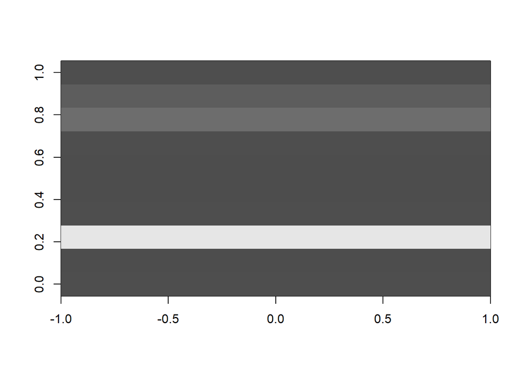

```r
displayDigit(d.bike.test.new[ref,-1])
```

```r
set.seed(13)
training <- d.bike.train.new[,-1]
test <- d.bike.test.new
test_total <- d.bike.new

h2o.init()
```

[output not shown]

```r
train_hf <- as.h2o(training)
set.seed(105)

model_dl <- h2o.deeplearning(y = 4, training_frame = train_hf, nfolds = 10, seed=500, verbose = F)
# prediction on TRAIN
predicted_h20_deep_neural_network_probabilites_train <- h2o.predict(model_dl, train_hf)
#table( as.data.frame(predicted_h20_deep_neural_network_probabilites_train$predict))
predicted_h20_deep_neural_network_class_train <- as.data.frame(predicted_h20_deep_neural_network_probabilites_train$predict)
#table(training$cnt, predicted_h20_deep_neural_network_class_train[,1])
predicted_h20_deep_neural_network_performance_train <- mean(predicted_h20_deep_neural_network_class_train[,1] == training$cnt)*100
print(paste('training accuracy: ',predicted_h20_deep_neural_network_performance_train,"%"))
```

```
## [1] "training accuracy:  1.00506367960718 %"
```

```r
# prediction on TEST
test_hf <- as.h2o(test)
predicted_h20_deep_neural_network_probabilites_test <- h2o.predict(model_dl, test_hf)
#table( as.data.frame(predicted_h20_deep_neural_network_probabilites_test$predict))
predicted_h20_deep_neural_network_class_test <- as.data.frame(predicted_h20_deep_neural_network_probabilites_test$predict)
#table(test$cnt, as.integer(predicted_h20_deep_neural_network_class_test[,1]))
predicted_h20_deep_neural_network_performance_test <- mean(predicted_h20_deep_neural_network_class_test[,1] == test$cnt)*100
print(paste('test accuracy: ',predicted_h20_deep_neural_network_performance_test,"%"))
```

```
## [1] "test accuracy:  1.21979286536249 %"
```

```r
set.seed(400)
(ref_test=sample(1:dim(test)[1], 10, replace=F))
```

```
##  [1] 1637 3958 3580 1756  156 1550 2573 3625  941 2815
```

```r
for (idx in ref_test){
  real_class =test[idx,1]
  prediction = predicted_h20_deep_neural_network_class_test[idx,1]
  correct = (as.integer(real_class)==as.integer(prediction))
  print(paste('Index ',idx,' class: ',(as.integer(real_class)-1)," --> predicted: ",prediction," [correct = ",correct,"]"))
  displayDigit(test_total[idx,-1])
  i <- readline(prompt="Press [enter] to continue")
}
```

```
## [1] "Index  1637  class:  3  --> predicted:  1  [correct =  FALSE ]"
```

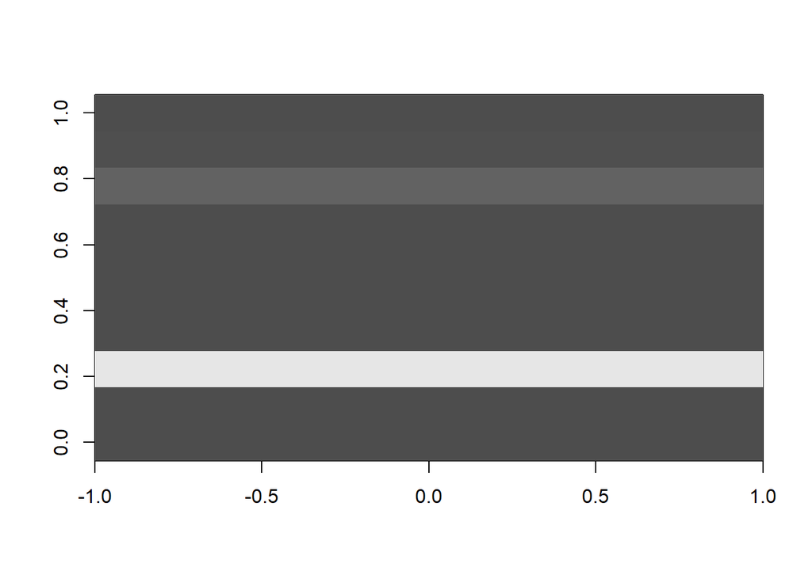

```
## Press [enter] to continue
## [1] "Index  3958  class:  3  --> predicted:  1  [correct =  FALSE ]"
```

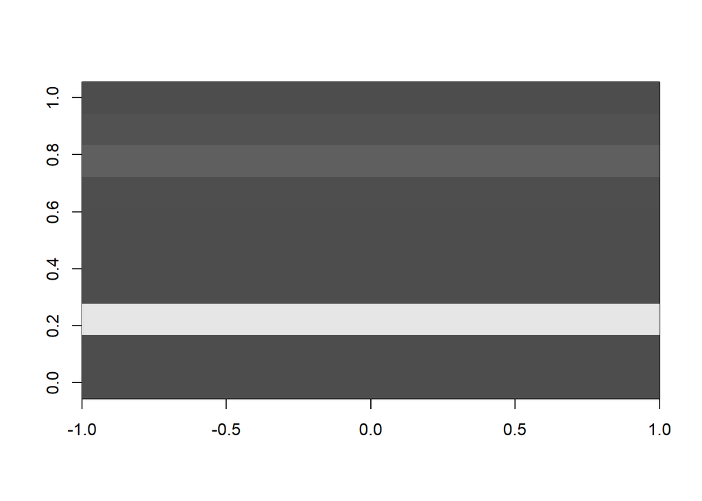

```
## Press [enter] to continue
## [1] "Index  3580  class:  2  --> predicted:  1  [correct =  FALSE ]"
```

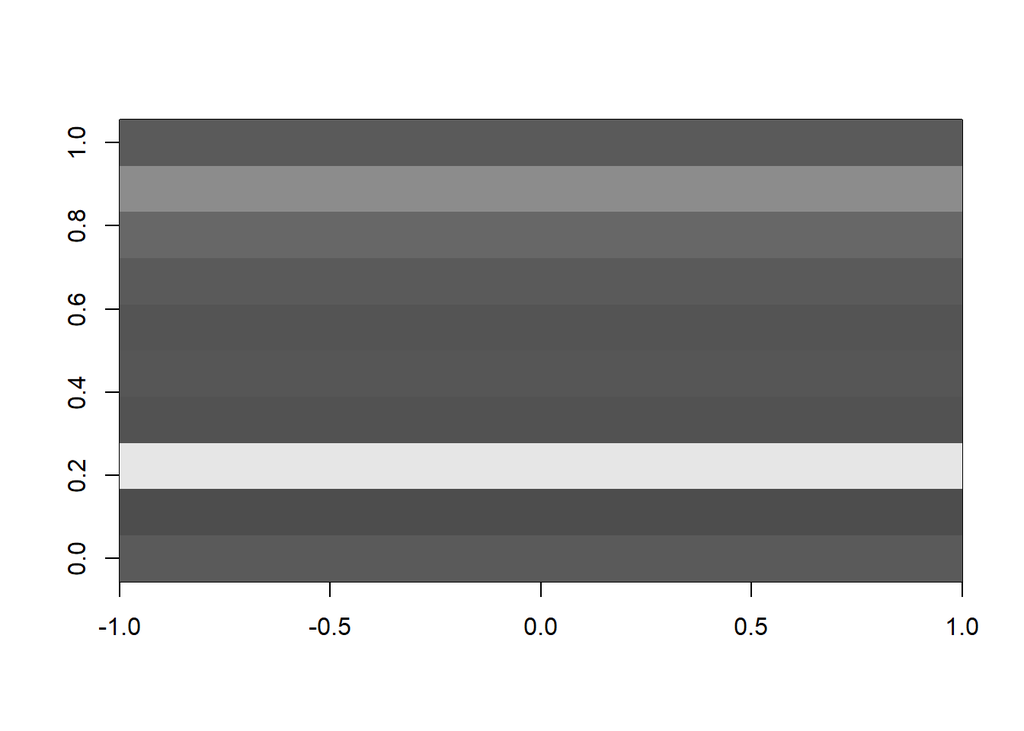

```
## Press [enter] to continue
## [1] "Index  1756  class:  3  --> predicted:  1  [correct =  FALSE ]"
```

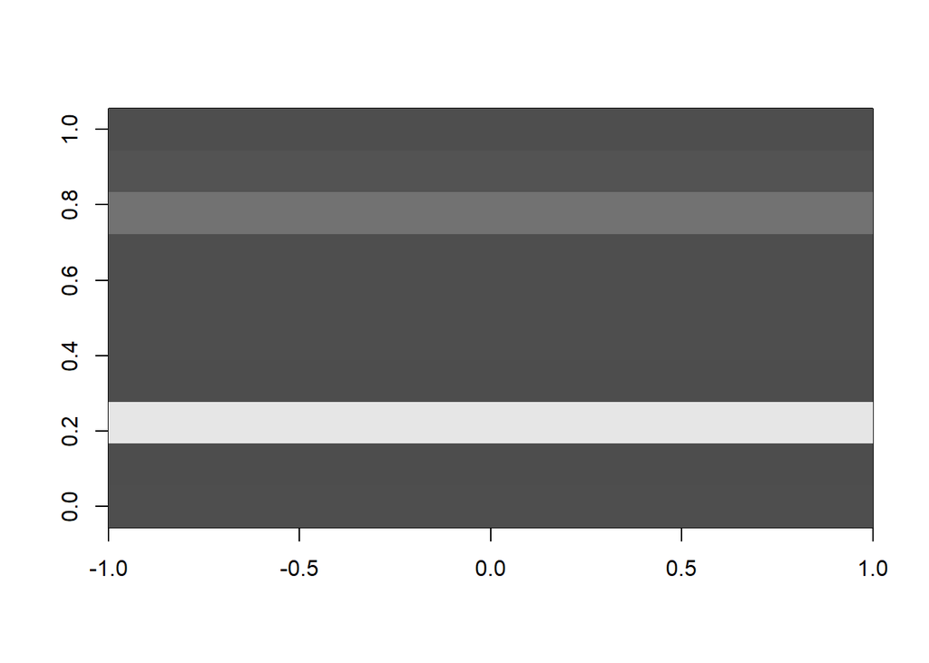

```
## Press [enter] to continue
## [1] "Index  156  class:  0  --> predicted:  2  [correct =  FALSE ]"
```

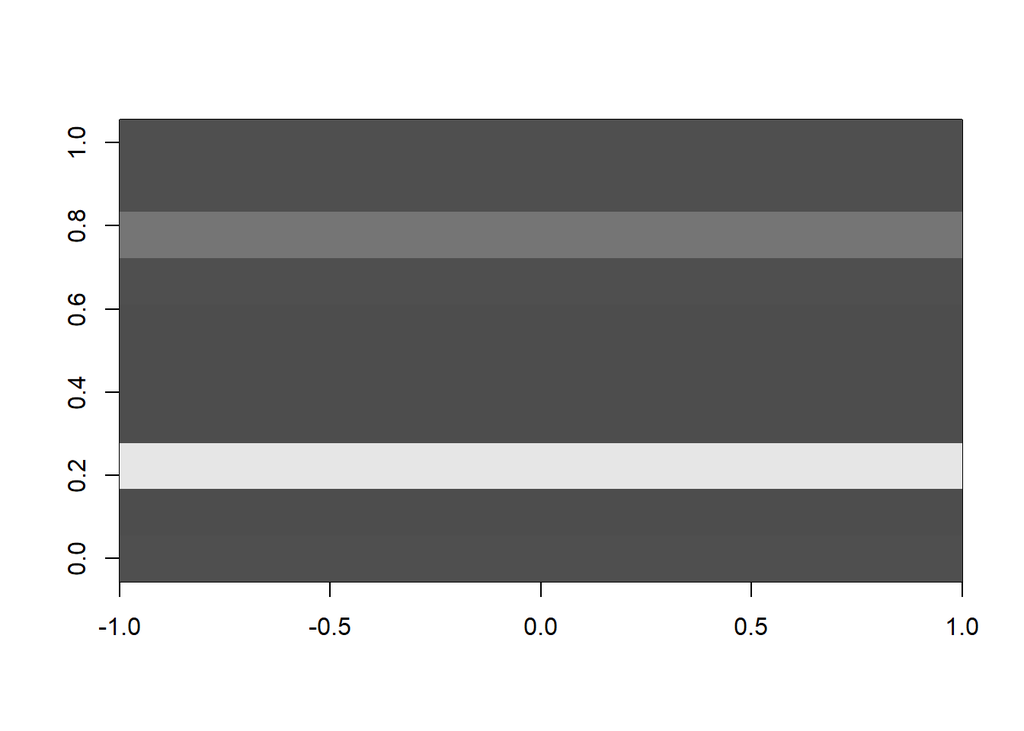

```
## Press [enter] to continue
## [1] "Index  1550  class:  2  --> predicted:  2  [correct =  FALSE ]"
```

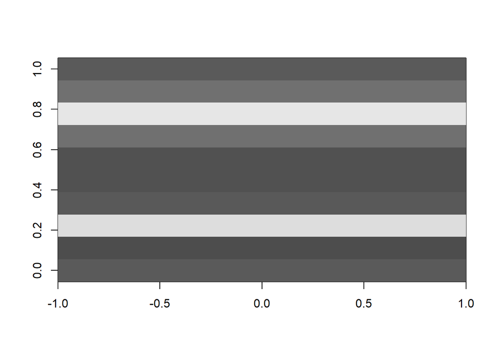

```
## Press [enter] to continue
## [1] "Index  2573  class:  0  --> predicted:  1  [correct =  TRUE ]"
```

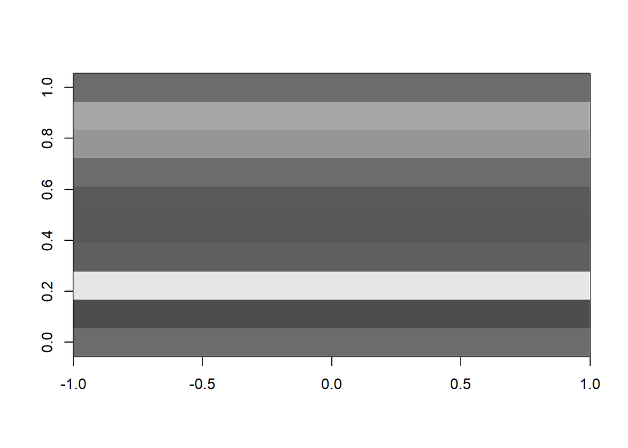

```
## Press [enter] to continue
## [1] "Index  3625  class:  2  --> predicted:  1  [correct =  FALSE ]"
```

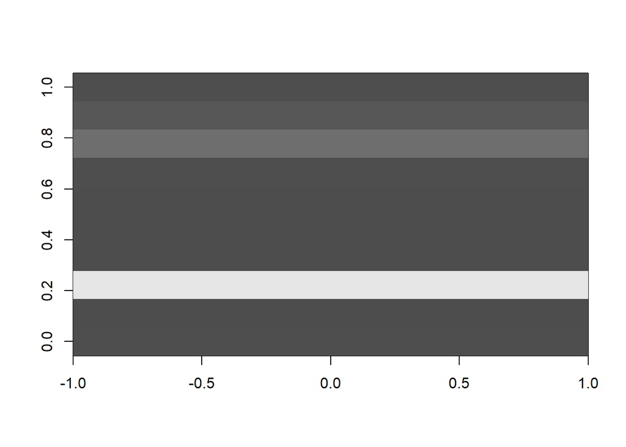

```
## Press [enter] to continue
## [1] "Index  941  class:  1  --> predicted:  1  [correct =  FALSE ]"
```

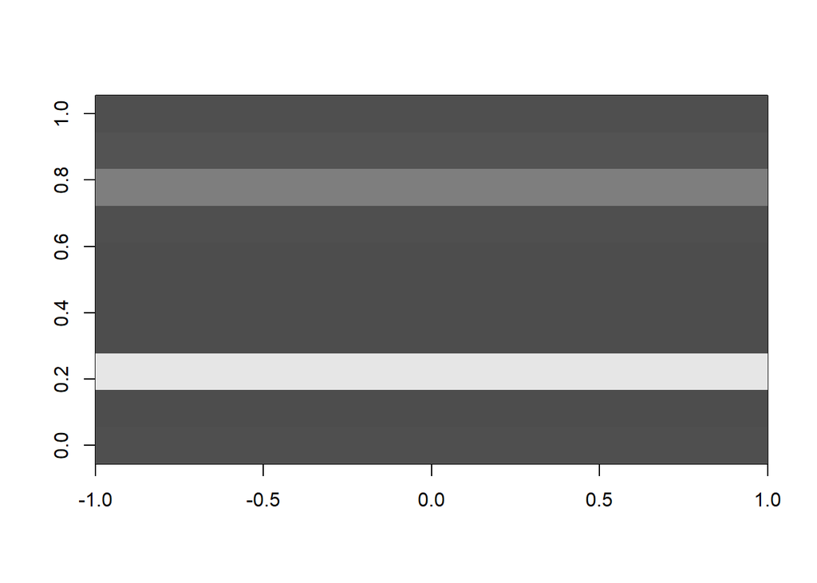

```
## Press [enter] to continue
## [1] "Index  2815  class:  1  --> predicted:  2  [correct =  TRUE ]"
```

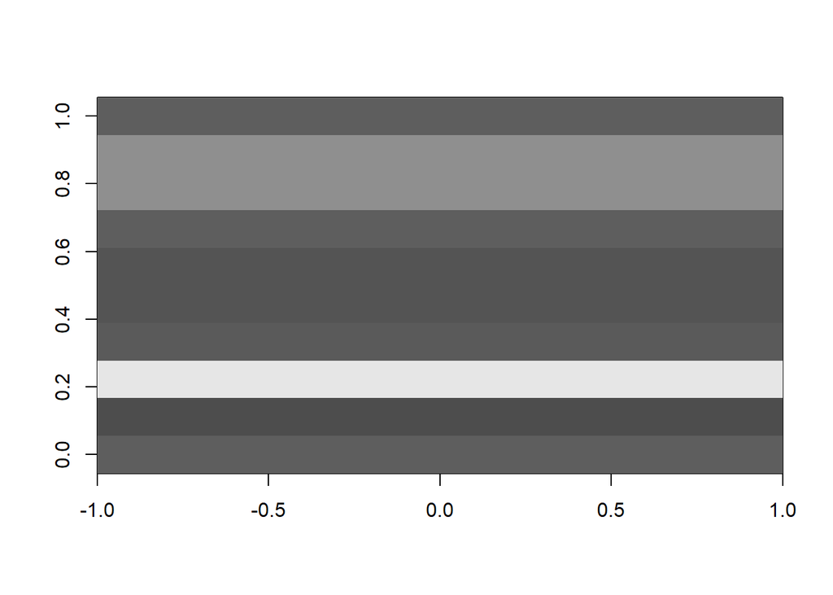

```
## Press [enter] to continue
```

# 7. Conclusion

The purpose of this chapter is to compare all the models that have been used in this work to analyze and predict bike rentals. The comparison takes place in two groups: Regression Problems and Classification Problems. The RMSE is used as comparison value for the regression problems and the accuracy is used for classification problems. To guarantee the fairness of the comparison, a 10-fold cross validation is applied.

```r
for(i in 1:10){
  d.bike.train.id <- sample(seq_len(nrow(d.bike.new)),size = floor(0.75*nrow(d.bike.new)))
  d.bike.train.new <- d.bike.new[d.bike.train.id,]
  d.bike.test.new <- d.bike.new[-d.bike.train.id,]

  #Linear Regression
  predicted.lm.bike.1.test <- predict(lm.bike.1.train,
                                      newdata = d.bike.test.new)
  r.squared.lm.bike.1 <- cor(predicted.lm.bike.1.test, d.bike.test.new$cnt)^2

  #Non-linear Regression
  predicted.gam.bike.1.test <- predict(gam.bike.1.train,
                                       newdata = d.bike.test.new)
  r.squared.gam.bike.1 <- cor(predicted.gam.bike.1.test, d.bike.test.new$cnt)^2

  #Poisson Regression
  predicted.poi.bike.1.test <- predict(poi.bike.1.train,
                                       newdata = d.bike.test.new)
  r.squared.poi.bike.1 <- cor(predicted.poi.bike.1.test, d.bike.test.new$cnt)^2

  #Regression Tree
  tree.regression.bike.pruned.test.pred <- predict(tree.regression.bike.pruned, d.bike.test.new, type="vector")
  (MSE.pruned.test <- mean(((d.bike.test.new["cnt"]-tree.regression.bike.pruned.test.pred)^2)$cnt))
  (RMSE.pruned.test <- sqrt(MSE.pruned.test))

  #Bagging
  yhat.bag = predict(bag.bike,newdata=d.bike.test.new)
  RMSE.bag <- sqrt(mean((yhat.bag-d.bike.test.new$cnt)^2))

  #Random Forest
  yhat.rf = predict(rf.bike ,newdata=d.bike.test.new)
  RMSE.rf <- sqrt(mean((yhat.rf-d.bike.test.new$class)^2))

  #Boosting
  yhat.boost=predict(boost.bike,newdata=d.bike.test.new, n.trees=1000)
  RMSE.boost <- sqrt(mean((yhat.boost -d.bike.test.new$cnt)^2))

  #Neural Network
  predicted_h20_deep_neural_network_probabilites_test <- h2o.predict(model_dl, test_hf)
  predicted_h20_deep_neural_network_performance_test <- mean(predicted_h20_deep_neural_network_class_test[,1] == test$cnt)*100

  #Classification Tree
  prune.tree.classification.bike.pred.test <- predict(prune.tree.classification.bike,  d.bike.test.new, type="class")
  (prune.tree.classification.bike.pred.test.ct <- table(prune.tree.classification.bike.pred.test, as.factor(d.bike.test.new$class)))
  (prune.tree.classification.bike.pred.test.correct <- sum(prune.tree.classification.bike.pred.test==as.factor(d.bike.test.new$class))/sum(prune.tree.classification.bike.pred.test.ct))

  #SVM
  predict.svm.bike.2.best.test <- predict(svm.bike.2.best, d.bike.test.svm)
  corrects=sum(predict.svm.bike.2.best.test==d.bike.test.svm$y)
  errors=sum(predict.svm.bike.2.best.test!=d.bike.test.svm$y)
  (performance_test=corrects/(corrects+errors))
}
#RMSE for Regression cases
lm.bike.1.rmse <- sqrt(mean(lm.bike.1$residuals^2))
gam.bike.1.rmse <- sqrt(mean(gam.bike.1$residuals^2))
poi.bike.1.rmse <- sqrt(mean(poi.bike.1$residuals^2))
regression.tree.rmse <- mean(RMSE.pruned.test)
bagging.rmse <- mean(RMSE.bag)
randomforest.rmse <- mean(RMSE.rf)
boosting.rmse <- mean(RMSE.boost)
#Accuracy for Classification
neuralnetwork.accuracy <- mean(predicted_h20_deep_neural_network_performance_test)/100
classification.tree.accuracy <- mean(prune.tree.classification.bike.pred.test.correct)
svm.accuracy <- mean(performance_test)

#Output
lm.bike.1.rmse
```

```
## [1] 91.21894
```

```r
gam.bike.1.rmse
```

```
## [1] 91.17963
```

```r
poi.bike.1.rmse
```

```
## [1] 91.21894
```

```r
regression.tree.rmse
```

```
## [1] 122.2583
```

```r
bagging.rmse
```

```
## [1] 52.03104
```

```r
randomforest.rmse
```

```
## [1] 0.3236751
```

```r
boosting.rmse
```

```
## [1] 258.8552
```

```r
neuralnetwork.accuracy
```

```
## [1] 0.01219793
```

```r
classification.tree.accuracy
```

```
## [1] 0.7132336
```

```r
svm.accuracy
```

```
## [1] 0.9997699
```

As the accuracy values of the classification models, i.e. the Neural Network, the Classification Tree and the SVM, show, the SVM with an accuracy of almost 100% is the best model in our analysis. The Classification Tree still classifies with an accuracy of about 70% while the Neural Network is far behind.

In conclusion, it can be said that several models are suitable for predicting bicycle rentals - either as a numerical value as in the regression models, or as a class as in the classification. The best ones include SVM, bagging, random forest and linear or non-linear regression models.